# Clinical report

[figure not shown]

Dr. Marsh Königs, m.konigs@amc.nl

##Visuomotor Tracking Test

Test details

| Test | Details |
| --- | --- |
| Subject | 110001 |
| Resolution (Hz) | 71 |

###Overall Performance

### Performance in Fixed Condition

| Metric | Speed 2 | Speed 4 | Speed 6 | Speed 8 |
| --- | --- | --- | --- | --- |
| Mean Deviation (Pixels) | 300 | 300 | 300 | 300 |
| SD of Deviation (Pixels) | 0 | 0 | 0 | 0 |
| Direction Changes (#) | 0 | 0 | 0 | 0 |

### Performance in Random Condition

| Metric | Speed 2 | Speed 4 | Speed 6 | Speed 8 |
| --- | --- | --- | --- | --- |
| Mean Deviation (Pixels) | 307 | 328 | 272 | 275 |
| SD of Deviation (Pixels) | 109 | 162 | 137 | 133 |
| Direction Changes (#) | 17 | 18 | 17 | 18 |

[figure not shown]

**Legend.** Visuomotor tracking performance in the fixed and random conditions as a function of speed.

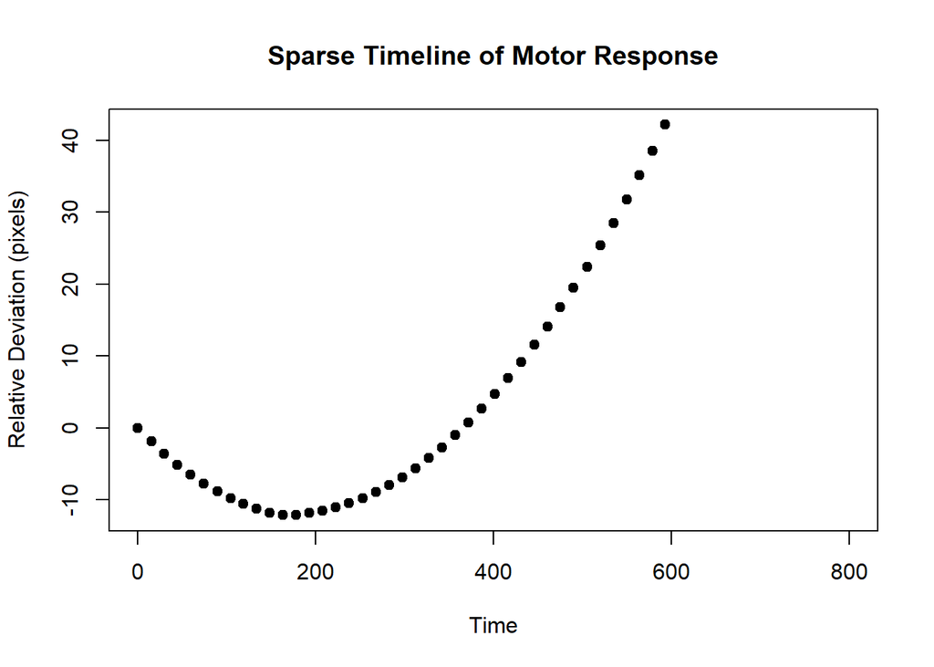

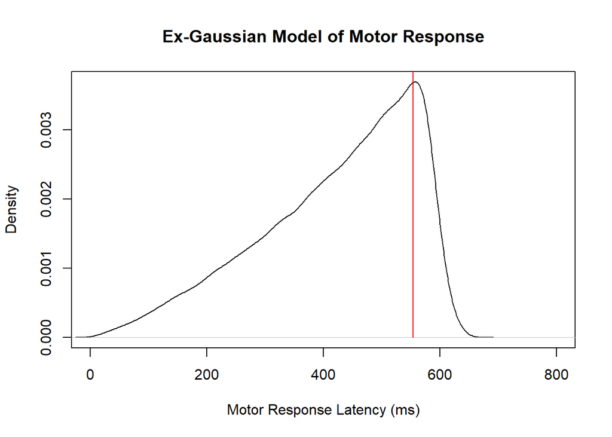

**Legend.** Estimated timeline of deviation from target, modeled from the sparse data collection using the Ex-gaussian model that mimics the shape of the response. The estimated timeline is only for visualization purposes, not for calculation. Due to the involvement of a randomization process during timeline estimation, its shape can vary slightly and the peak can show a slight mismatch with the estimated motor response delay. The estimated motor response delay is calculated on the actual response time distribution, is not dependent on randomization and therefore always produces the same results on the same dataset.

[1] “Estimated Motor Response Delay (ms): 554”

0